# Communicate Data Findings: Prosper Loan Data

### Yagmur Dalman

## Investigation Overview

In this investigation, I wanted to look at the the effects of some variables on the Borrower APR. The main focus was on the variables Prosper Score and Loan Original Amount.

## Dataset Overview

This data set contains 113,937 loans with 81 variables on each loan, including Borrower APR, Prosper Score, Loan Amount, Loan Status, Stated Monthly Income, and many others. I choose 14 variables for my analysis. After necessary data cleaning, data size decreased to 75,774.

## Distribution of Borrower APR

Borrower APR is the cost of credit as a yearly rate, and the sum of the interest rate and the other fees.

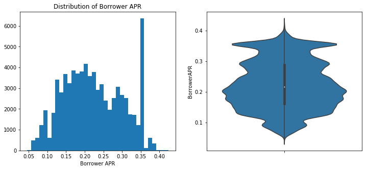

```python
plt.figure(figsize = [12, 5])

plt.subplot(1,2,1)
plt.hist(data=df, x='BorrowerAPR', bins=35);
plt.title('Distribution of Borrower APR');
plt.xlabel('Borrower APR')

plt.subplot(1,2,2)
sb.violinplot(data = df, y = 'BorrowerAPR', color = base_color);
```

## Distribution of Prosper Score

Prosper Score is the custom risk score was built using historical Prosper data to assess the risk of Prosper borrower listings. The output to Prosper users is a Prosper score which ranges from 1 to 11, with 11 being the best and 1 being the worst.

Its distribution is multimodal and has three peaks at 4, 6 and 8. The mean risk score is 6.

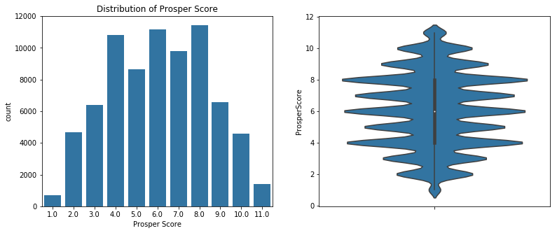

```python
plt.figure(figsize = [13, 5])

plt.subplot(1,2,1)
sb.countplot(data = df, x = 'ProsperScore', color= base_color);
plt.xlabel('Prosper Score')
plt.title('Distribution of Prosper Score')

plt.subplot(1,2,2)
sb.violinplot(data = df, y = 'ProsperScore', color= base_color);
```

## Distribution of Loan Original Amount

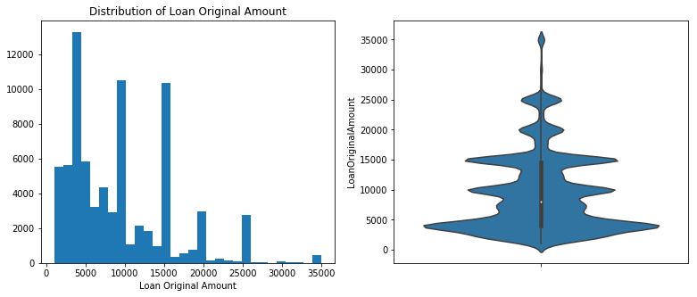

```python
plt.figure(figsize = [13, 5])

plt.subplot(1,2,1)
plt.hist(data=df, x='LoanOriginalAmount', bins=30);
plt.xlabel('Loan Original Amount')
plt.title('Distribution of Loan Original Amount')

plt.subplot(1,2,2)
sb.violinplot(data = df, y = 'LoanOriginalAmount', color= base_color);
```

## Distribution of Debt to Income Ratio

The ratio actually varies from 0 to 10 but there is a small number of borrowers with debt to income ratio greater than 1 so I limit ratio by 1. The distribution is unimodal and skewed right. The mean ratio around 0.25 which means that borrowers get loans about 25% of their income.

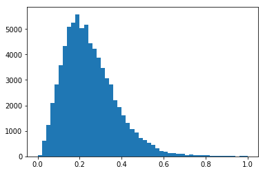

```python
bins = np.arange(0, df.DebtToIncomeRatio.max()+ 0.02, 0.02)
plt.hist(data = df, x = 'DebtToIncomeRatio',bins=bins);
```

## Borrower APR vs. Prosper Score

It can be clearly seen that there is a negative correlation between Prosper Score and Borrower APR, which means that people with lower credit risk score pay more for the loan. The rate is even small as 0.05 for the borrower with risk score 10. This relationship is not surprising because the borrowers with high Prosper Score may be considered as trustworthy people and they are believed to pay their debts on time so get lower Borrower APR. Of course, a good Prosper Score is not enough for such a conclusion but we cannot deny its effect on Borrower APR.

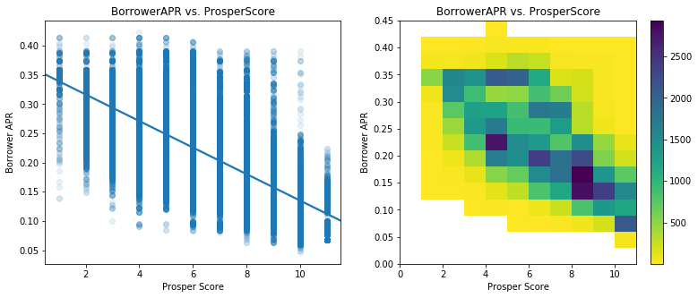

```python
# scatter and heat plots for ProsperScore and BorrowerAPR.
plt.figure(figsize = [13, 5])

plt.subplot(1, 2, 1)
sb.regplot(data = df, x = 'ProsperScore', y = 'BorrowerAPR', scatter_kws = {'alpha' : 1/10});
plt.title('BorrowerAPR vs. ProsperScore')
plt.ylabel('Borrower APR')
plt.xlabel('Prosper Score')

plt.subplot(1, 2, 2)
bins_x = np.arange(0, df['ProsperScore'].max()+1, 1)
bins_y = np.arange(0, df['BorrowerAPR'].max()+0.03, 0.03)
plt.hist2d(data = df, x = 'ProsperScore', y = 'BorrowerAPR', bins = [bins_x, bins_y], cmap = 'viridis_r', cmin = 0.5)
plt.colorbar()
plt.title('BorrowerAPR vs. ProsperScore')
plt.ylabel('Borrower APR')
plt.xlabel('Prosper Score');
```

## Borrower APR vs. Loan Original Amount

There is a negative interaction between Borrower APR and Loan Amount. For small amount of loans, borrowers get higher Borrower APRs. From the scatter plot, we can also infer that while the Borrower APR for the lower loans are more diversified, for the higher amount of loans it's range is getting narrower. One reason for that might be borrowers' Prosper Scores. Probably the high amount of loans are mostly given to the borrowers with high Prosper scores.

Since the points are too intensive in the scatter plot, I also provide line plot which displays the relationship between average Borrower APR and Loan Amount. It can be seen that they are negativetly correlated but the line is not smooth. After decreasing to %15 in between 20k and 25k, Borrower APR begin to rise again until around 27k and right after that it drops even more.

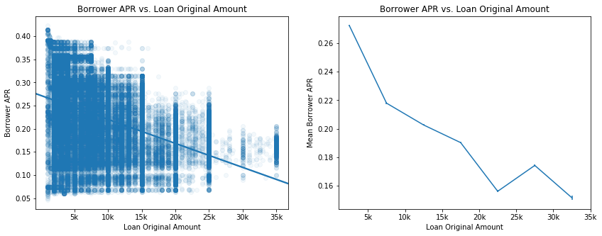

```python
plt.figure(figsize = (14,5))

plt.subplot(1,2,1)
sb.regplot(data = df, x = 'LoanOriginalAmount', y = 'BorrowerAPR', scatter_kws = {'alpha' : 1/20});
plt.xticks([5000, 10000, 15000, 20000, 25000, 30000, 35000], ['5k', '10k', '15k', '20k', '25k', '30k', '35k'])
plt.xlabel('Loan Original Amount');
plt.ylabel('Borrower APR');
plt.title('Borrower APR vs. Loan Original Amount')
plt.subplot(1,2,2)
xbin_edges = np.arange(0, df['LoanOriginalAmount'].max()+5000, 5000)
xbin_centers = (xbin_edges + 2500)[:-1]
# compute statistics in each bin
data_xbins = pd.cut(df['LoanOriginalAmount'], xbin_edges, right = False, include_lowest = True)
y_means = df['BorrowerAPR'].groupby(data_xbins).mean()
y_sems = df['BorrowerAPR'].groupby(data_xbins).sem()
# plot the summarized data
plt.errorbar(x = xbin_centers, y = y_means, yerr = y_sems);
plt.xlabel('Loan Original Amount');
plt.ylabel('Mean Borrower APR');
plt.title('Borrower APR vs. Loan Original Amount')
plt.xticks([5000, 10000, 15000, 20000, 25000, 30000, 35000], ['5k', '10k', '15k', '20k', '25k', '30k', '35k']);
```

## Borrower APR vs. Debt to Income Ratio

Borrower APR and Debt to Income Ratio are positively correlated. When the proportion of debt to income increases the Borrower APR also increases. If we have a closer look to the plots, we can see that while Borrower APR varies more and the loan data is more dense for Debt to Income Ratio values between 0 and 0.3, it does not hold for the higher values.

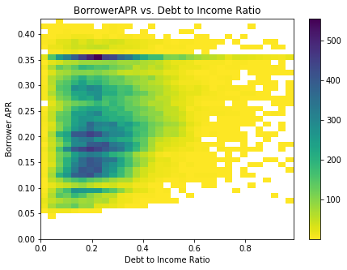

```python
plt.figure(figsize = [7, 5])

bins_x = np.arange(0, df['DebtToIncomeRatio'].max()+0.03, 0.03)
bins_y = np.arange(0, df['BorrowerAPR'].max()+0.01, 0.01)
plt.hist2d(data = df, x = 'DebtToIncomeRatio', y = 'BorrowerAPR', bins = [bins_x, bins_y],
           cmap = 'viridis_r', cmin = 0.5)
plt.colorbar();
plt.title('BorrowerAPR vs. Debt to Income Ratio')
plt.ylabel('Borrower APR')
plt.xlabel('Debt to Income Ratio');
```

## Prosper Score vs. Loan Original Amount

As it can be seen from both plots, Loan Amount increases in Prosper Score so there is a positive correlation between two but it doesn't seem strong. Also, Prosper Score varies more for the small amount of loans.

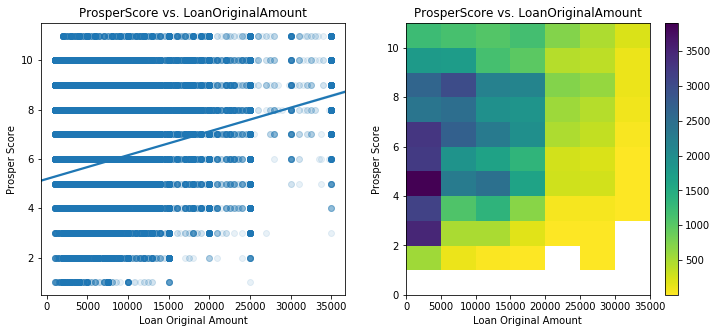

```python
plt.figure(figsize = [12, 5]);

plt.subplot(1, 2, 1)
sb.regplot(data = df, x = 'LoanOriginalAmount', y = 'ProsperScore', scatter_kws = {'alpha' : 1/10});
plt.title('ProsperScore vs. LoanOriginalAmount')
plt.ylabel('Prosper Score')
plt.xlabel('Loan Original Amount');

plt.subplot(1, 2, 2)
bins_x = np.arange(0, df['LoanOriginalAmount'].max()+5000, 5000)
bins_y = np.arange(0, df['ProsperScore'].max()+1, 1)
plt.hist2d(data = df, x = 'LoanOriginalAmount', y = 'ProsperScore', bins = [bins_x, bins_y], cmap = 'viridis_r', cmin = 0.5)
plt.colorbar();
plt.title('ProsperScore vs. LoanOriginalAmount')
plt.ylabel('Prosper Score')
plt.xlabel('Loan Original Amount');
```

## Borrower APR & Term

The number of loans with 12-month length are smaller which means that people generally take loans for larger periods. The mean Borrower APR for 12-month loans is the smallest one. While the Borrower APR range is pretty much similar for 12-month and 36-month loans, it is narrower for 60-month loans. Conventionally, I would expect that 60-month loans having the highest mean Borrower APR but 36-month loans have the highest. There are probably some other causal factors and I belive Prosper Score is one of them.

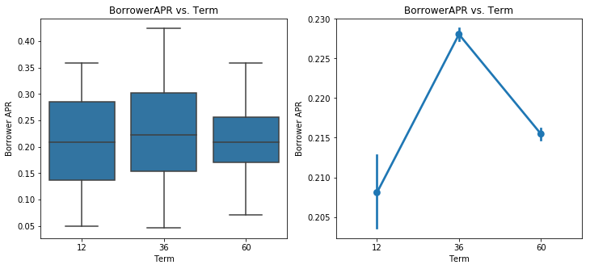

```python
plt.figure(figsize = [12, 5])

plt.subplot(1, 2, 1)
sb.boxplot(data = df, x = 'Term', y = 'BorrowerAPR', color = base_color);
plt.title('BorrowerAPR vs. Term')
plt.ylabel('Borrower APR')
plt.xlabel('Term');

plt.subplot(1, 2, 2)
sb.pointplot(data = df, x = 'Term', y = 'BorrowerAPR');
plt.title('BorrowerAPR vs. Term')
plt.ylabel('Borrower APR')
plt.xlabel('Term');
```

## Borrower APR & Prosper Score by Term

Term does not have a fixed effect on the relationship between Borrower APR and Prosper Score. However, it has a consistent behavior if we do our analysis by dividing scores into intervals. While the borrowers with score greater than 7 pay more for the 60-month loans while it is the opposite for the scores from 3 to 7.

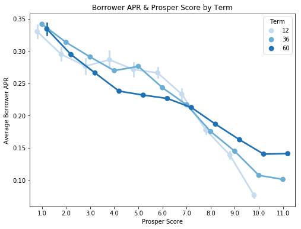

```python
fig = plt.figure(figsize = [8,6])
ax = sb.pointplot(data = df, x = 'ProsperScore', y = 'BorrowerAPR', hue = 'Term',
           palette = 'Blues', dodge = 0.4)
ax.set_yticklabels([],minor = True)
plt.title('Borrower APR & Prosper Score by Term')
plt.ylabel('Average Borrower APR')
plt.xlabel('Prosper Score');
plt.show();
```

## Borrower APR & Loan Original Amount by Term

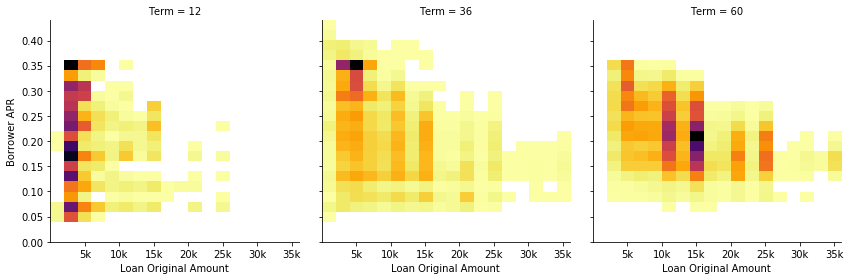

```python
def hist2dgrid(x, y, **kwargs):
    """ Quick hack for creating heat maps with seaborn's PairGrid. """
    palette = kwargs.pop('color')
    bins_y = np.arange(0, df.BorrowerAPR.max()+.02, .02)
    bins_x = np.arange(0, df.LoanOriginalAmount.max()+2000, 2000)
    plt.hist2d(x, y, bins = [bins_x, bins_y], cmap = palette, cmin = 0.5)

# create faceted heat maps on levels of the term variable
g = sb.FacetGrid(data = df, col = 'Term', size = 4)
g.map(hist2dgrid, 'LoanOriginalAmount', 'BorrowerAPR', color = 'inferno_r')
g.set_xlabels('Loan Original Amount')
g.set_ylabels('Borrower APR')
# plt.title('Relationship of BorrowerAPR and Loan Original Amount for Different Terms')
plt.xticks([5000, 10000, 15000, 20000, 25000, 30000, 35000], ['5k', '10k', '15k', '20k', '25k', '30k', '35k'])
plt.show()
```

## Borrower APR & Debt To Income Ratio across Terms

For the Debt to income ratios between 0-0.3, while the Borrower APR changes from 0.05 to 0.035 for 12-month and 36-month loans, its range is gets narrower for 60-month loans.

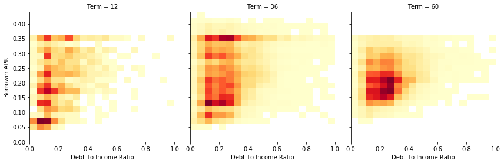

```python
def hist2dgrid(x, y, **kwargs):
    """ Quick hack for creating heat maps with seaborn's PairGrid. """
    palette = kwargs.pop('color')
    bins_y = np.arange(0, df.BorrowerAPR.max()+.02, .02)
    bins_x = np.arange(0, df.DebtToIncomeRatio.max()+0.05, 0.05)
    plt.hist2d(x, y, bins = [bins_x, bins_y], cmap = palette, cmin = 0.5)

g = sb.FacetGrid(data = df, col = 'Term', size = 4)
g.map(hist2dgrid, 'DebtToIncomeRatio', 'BorrowerAPR', color = 'YlOrRd')
g.set_xlabels('Debt To Income Ratio')
g.set_ylabels('Borrower APR')
plt.show()
```

## Borrower APR vs. Prosper Score by Borrower Type

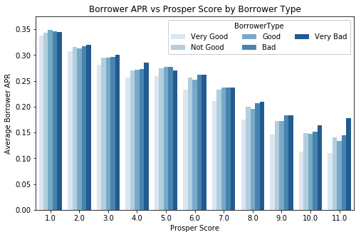

```python
plt.figure(figsize = [8, 5])

ax = sb.barplot(data = df, x = 'ProsperScore', y = 'BorrowerAPR', hue = 'BorrowerType',
                palette='Blues', errwidth =0);
ax.legend(loc = 1, ncol = 3, framealpha = 1, title = 'BorrowerType');
plt.title('Borrower APR vs Prosper Score by Borrower Type')
plt.ylabel('Average Borrower APR')
plt.xlabel('Prosper Score');
plt.show();
```

## Role of Home ownership on the relationship between Loan Original Amount and Prosper Score

In the same Prosper score level, it seems like the homeowners take out larger amount of loans comparing to the non homeowners.

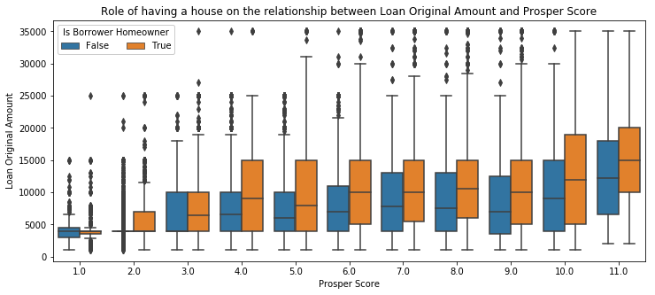

```python
plt.figure(figsize = [12, 5])

ax = sb.boxplot(data = df, x = 'ProsperScore', y = 'LoanOriginalAmount', hue = 'IsBorrowerHomeowner');
ax.legend(loc = 2, ncol = 3, framealpha = 1, title = 'Is Borrower Homeowner');
plt.title('Role of having a house on the relationship between Loan Original Amount and Prosper Score')
plt.ylabel('Loan Original Amount')
plt.xlabel('Prosper Score');
```

## Prosper Score vs. Loan Original Amount by Term

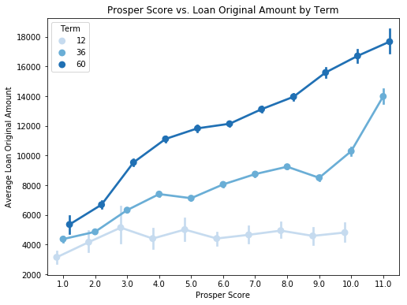

```python
fig = plt.figure(figsize = [8,6])
ax = sb.pointplot(data = df, x = 'ProsperScore', y = 'LoanOriginalAmount', hue = 'Term',
           palette = 'Blues', dodge = 0.4)
ax.set_yticklabels([],minor = True)
plt.title('Prosper Score vs. Loan Original Amount by Term')
plt.ylabel('Average Loan Original Amount')
plt.xlabel('Prosper Score');

plt.show();
```